limma result categories

limma analysis results can be divided into three categories, which are defined in this document.

# Time Effect: This category focuses on the changes of the feature (e.g. protein) value that occur over time within a single condition.

# Average Difference Between Conditions: This category compares the average feature values for levels within a condition, regardless of time.

# Interaction Between Condition and Time: This category examines the interaction between time and condition. It identifies features whose value changes differently over time depending on the condition.

# Legend:

A hit is a feature (e.g. a protein) that is significantly changed over the time.

Levels are the different factors of a condition of the experiment. For example, bioreactor phase is a condition, and exponential and stationary are levels within that condition.

Category 1 (time effect)

Temporal pattern within level for a given feature  Hit

Example for a hit

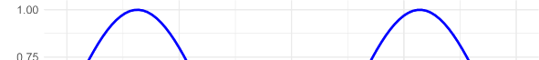

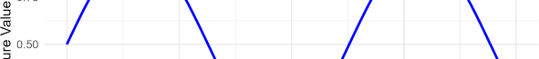

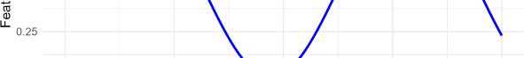

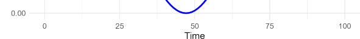

Example of a feature that is no hit

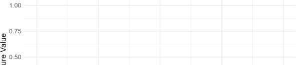

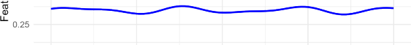

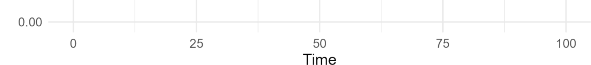

Figure 2: No clear temporal pattern  no hit for category 1.

Category 2 (average difference conditions)

Overall mean difference between levels for a given feature  Hit

Example for a hit

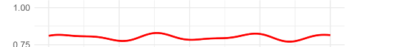

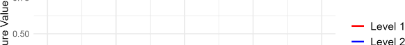

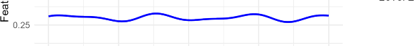

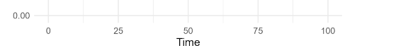

Example for a feature which is no hit

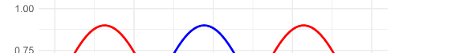

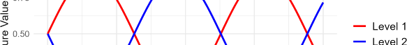

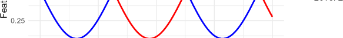

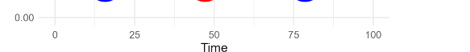

Figure 4: Clear temporal pattern for both levels but no overall mean difference in feature value between them  no hit for category 2.

Category 3 (interaction condition & time)

Treatment interacting with time for a feature (time effect changing with treatment, the feature must have different temporal patterns in both conditions/levels)  Hit

Examples for hits

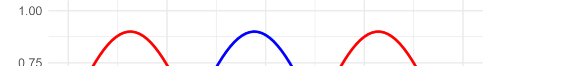

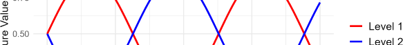

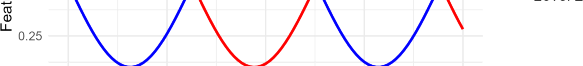

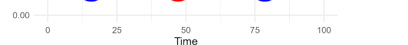

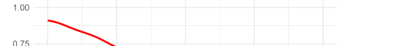

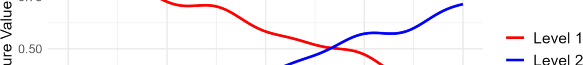

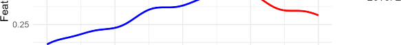

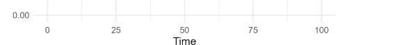

Figure 6: Different temporal patterns of the feature for both levels  hit in category 3.

Example of a features that is no hit

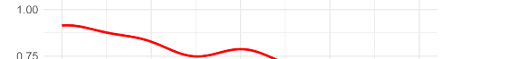

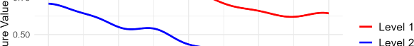

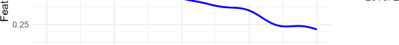

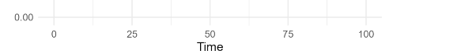

Figure 7: Overall the same temporal pattern of a feature for both levels  no hit for category 3.